# RNASeq workshop 2017; DESeq2

Miriam Payá Milans

June 16, 2017

## Data pre-processing

In this lab, we will use the count results after applying the same pipeline taught in the workshop on multiple and larger fastq files. [Download the deseq2.zip](https://github.com/statonlab/rnaseq_workshop/raw/master/deseq2/deseq2.zip) file into your Desktop and unzip it; it will create a deseq2 folder. Change the path in `setwd()` to point to this folder.

```r
setwd("E:/UT/rnaseq_ws/2017/deseq2")
library(DESeq2)
```

### Count data files

After running HTSeq-count, we get output files on 2-column format, where the first column contain the gene names and the second column the gene counts, or number of reads mapped to that gene. This is how they look like.

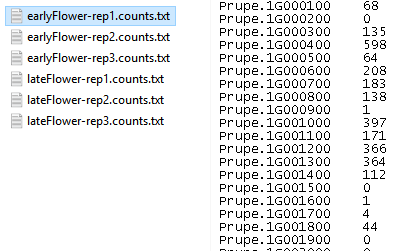

Count data files

The first step is to load the files into the R session using the `DESeqDataSetFromHTSeqCount()` function, which generates an object recognized by `DESeq()`. To do so, we need to generate a table specifying the following: * The sample name in the first column, * The count file name on the second column * Metadata on the remaining columns

We are going to collect all this information from the file names.

```r
## get file names
fileName <- list.files(path = "./countData/", pattern = "*.txt")
fileName
```

```
## [1] "earlyFlower-rep1.counts.txt" "earlyFlower-rep2.counts.txt"
## [3] "earlyFlower-rep3.counts.txt" "lateFlower-rep1.counts.txt"
## [5] "lateFlower-rep2.counts.txt"  "lateFlower-rep3.counts.txt"
```

```r
## get sample names
sampleName <- sapply(strsplit(fileName, "[.]"), "[[", 1)
sampleName
```

```
## [1] "earlyFlower-rep1" "earlyFlower-rep2" "earlyFlower-rep3"
## [4] "lateFlower-rep1"  "lateFlower-rep2"  "lateFlower-rep3"
```

```r
## get phenotypes
pheno <-  sapply(strsplit(fileName, "-"), "[[", 1)
pheno <- as.factor(pheno)
pheno
```

```
## [1] earlyFlower earlyFlower earlyFlower lateFlower  lateFlower  lateFlower
## Levels: earlyFlower lateFlower
```

```r
## build the sample table
mySampleTable <- data.frame(sampleName, fileName, pheno)
mySampleTable
```

```
##         sampleName                    fileName       pheno
## 1 earlyFlower-rep1 earlyFlower-rep1.counts.txt earlyFlower
## 2 earlyFlower-rep2 earlyFlower-rep2.counts.txt earlyFlower
## 3 earlyFlower-rep3 earlyFlower-rep3.counts.txt earlyFlower
## 4  lateFlower-rep1  lateFlower-rep1.counts.txt  lateFlower
## 5  lateFlower-rep2  lateFlower-rep2.counts.txt  lateFlower
## 6  lateFlower-rep3  lateFlower-rep3.counts.txt  lateFlower
```

With this table, we are ready to load the count data.

### DESeqDataSet object: the data structure that `DESeq()` can recognize

The core function for differential analysis is `DESeq()`. But before we can use it, we need to preprocess our data so that the `DESeq()` function can recognize it.

```r
## get DESeqDataSet object
myDESeqData <- DESeqDataSetFromHTSeqCount(sampleTable = mySampleTable,
                                         directory = './countData', design = ~pheno)
myDESeqData
```

```
## class: DESeqDataSet
## dim: 26873 6
## metadata(0):
## assays(1): counts
## rownames(26873): Prupe.1G000100 Prupe.1G000200 ... Prupe.I006100
##   Prupe.I006200
## rowRanges metadata column names(0):
## colnames(6): earlyFlower-rep1 earlyFlower-rep2 ... lateFlower-rep2
##   lateFlower-rep3
## colData names(1): pheno
```

After loading our files, we’ll have a data matrix showing gene expression levels, with genes in rows and samples in columns

- 26873 genes
- Two genotypes with distinct phenotypes
- Each genotype has 3 clonal replicates

```r
head(counts(myDESeqData))
```

```
##                earlyFlower-rep1 earlyFlower-rep2 earlyFlower-rep3
## Prupe.1G000100               68               36               20
## Prupe.1G000200                0                0                0
## Prupe.1G000300              135               87               52
## Prupe.1G000400              598              509              149
## Prupe.1G000500               64              101               22
## Prupe.1G000600              208              177              148
##                lateFlower-rep1 lateFlower-rep2 lateFlower-rep3
## Prupe.1G000100             112              83              79
## Prupe.1G000200               0               0               0
## Prupe.1G000300             168             141             134
## Prupe.1G000400             261             304             245
## Prupe.1G000500             131             151              55
## Prupe.1G000600             234             242             202
```

### Pre-filtering

Filtering of low count data is not necessary to run DESeq, but it can reduce memory usage in cases where large data files are being used.

```r
dim(myDESeqData)
```

```
## [1] 26873     6
```

```r
myDESeqData <- myDESeqData[ rowSums(counts(myDESeqData)) > 1, ]
dim(myDESeqData)
```

```
## [1] 22605     6
```

## Differential expression analysis

- The necessary steps for differential expression analysis are wrapped into a single function `DESeq()`.
- Results are extracted using `results()`.

```r
myDESeq.Res <- DESeq(myDESeqData)
myRes <- results(myDESeq.Res, alpha=0.05)
summary(myRes)
```

```
##
## out of 22605 with nonzero total read count
## adjusted p-value < 0.05
## LFC > 0 (up)     : 1907, 8.4%
## LFC < 0 (down)   : 2281, 10%
## outliers [1]     : 48, 0.21%
## low counts [2]   : 2191, 9.7%
## (mean count < 1)
## [1] see 'cooksCutoff' argument of ?results
## [2] see 'independentFiltering' argument of ?results
```

```r
myRes
```

```
## log2 fold change (MAP): pheno lateFlower vs earlyFlower
## Wald test p-value: pheno lateFlower vs earlyFlower
## DataFrame with 22605 rows and 6 columns
##                  baseMean log2FoldChange     lfcSE        stat      pvalue
##                 <numeric>      <numeric> <numeric>   <numeric>   <numeric>
## Prupe.1G000100   60.56384      0.6569257 0.3625698   1.8118601 0.070007811
## Prupe.1G000300  112.75275      0.2162831 0.2799481   0.7725830 0.439769184
## Prupe.1G000400  338.30108     -0.9944857 0.3399244  -2.9256083 0.003437835
## Prupe.1G000500   78.54017      0.3852222 0.4383041   0.8788925 0.379459587
## Prupe.1G000600  199.66717     -0.1831100 0.2285344  -0.8012361 0.422994959
## ...                   ...            ...       ...         ...         ...
## Prupe.I005600    1.019084     -0.0141863 0.9402714 -0.01508746   0.9879624
## Prupe.I005700   51.990397      0.6365828 0.5311658  1.19846344   0.2307366
## Prupe.I005800  135.604067      0.7701920 0.4993929  1.54225672   0.1230112
## Prupe.I006100   14.448017      0.6705247 0.4798343  1.39740884   0.1622907
## Prupe.I006200   60.923767     -0.2142775 0.2808703 -0.76290567   0.4455197
##                      padj
##                 <numeric>
## Prupe.1G000100 0.20844723
## Prupe.1G000300 0.67473885
## Prupe.1G000400 0.02081537
## Prupe.1G000500 0.62065791
## Prupe.1G000600 0.66102270
## ...                   ...
## Prupe.I005600          NA
## Prupe.I005700   0.4611563
## Prupe.I005800   0.3069779
## Prupe.I006100   0.3681306
## Prupe.I006200   0.6795498
```

### Cases where NA values appear

- In cases where all samples have zero counts, log2FoldChange, pvalue and padj will be NA. We won’t see that here because we already filtered out these genes
- When a sample has an extreme count outlier, the pvalue and padj will also be NA
- Genes with low mean normalized counts are filtered out by automatic independent filtering and padj is NA.

The goal is to filter out tests that have no or little chance of showing significant evidence + This filtering results in increased detection power at the same False Discovery Rate (FDR, also type I error) + Independent filtering can be turned off in `DESeq()`

### p-value, adjusted p-value (padj) and alpha

On the results table, p-values are calculated with a single test. These need to be adjusted to control for type I error (False Discovery Rate) with multiple testing. By default, `DESeq()` applies the Benjamini-Hochberg procedure (BH). The result of multitesting are adjusted p-values, which are used to determine significant genes when they are below a cutoff. By default, FDR cutoff `alpha` is set to 0.1, although it can be modified in `results()`

```r
pvalues <- subset(myRes, !is.na(padj))[,'pvalue']
my.padj <- p.adjust(pvalues, method='BH') ## calculate adjusted p-value
my.padj[1:30] ## compare your adjusted p-values with the values from the results table
```

```
##  [1] 2.084472e-01 6.747389e-01 2.081537e-02 6.206579e-01 6.610227e-01
##  [6] 7.355507e-01 3.538100e-02 9.958937e-01 9.846981e-01 9.539529e-01
## [11] 6.402219e-01 3.841359e-01 5.838030e-01 4.501691e-01 7.914164e-01
## [16] 4.645318e-05 5.339547e-01 5.167517e-01 1.267665e-01 3.568927e-01
## [21] 7.177938e-01 2.077643e-01 6.054953e-01 2.342251e-01 6.624397e-01
## [26] 6.838730e-01 1.363725e-02 3.078908e-01 8.136836e-06 3.328035e-01
```

```r
subset(myRes, !is.na(padj))[,'padj'][1:30]
```

```
##  [1] 2.084472e-01 6.747389e-01 2.081537e-02 6.206579e-01 6.610227e-01
##  [6] 7.355507e-01 3.538100e-02 9.958937e-01 9.846981e-01 9.539529e-01
## [11] 6.402219e-01 3.841359e-01 5.838030e-01 4.501691e-01 7.914164e-01
## [16] 4.645318e-05 5.339547e-01 5.167517e-01 1.267665e-01 3.568927e-01
## [21] 7.177938e-01 2.077643e-01 6.054953e-01 2.342251e-01 6.624397e-01
## [26] 6.838730e-01 1.363725e-02 3.078908e-01 8.136836e-06 3.328035e-01
```

### Visualization of expression data after DESeq

The function plotMA shows the log2 fold changes, coloring points in red if the adjusted p-value is less than 0.05.

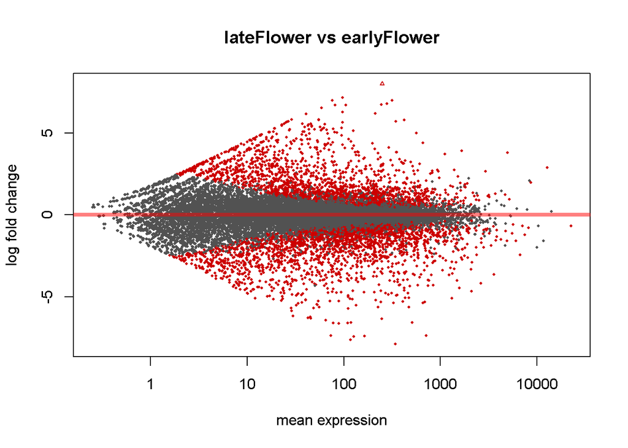

```r
plotMA(myRes, main="lateFlower vs earlyFlower", ylim=c(-8,8))
```

## Export results into a tab separated file

Here, we are going to export significant results only.

```r
myRes.sig <- subset(myRes, padj < 0.05)
myRes.sig
```

```
## log2 fold change (MAP): pheno lateFlower vs earlyFlower
## Wald test p-value: pheno lateFlower vs earlyFlower
## DataFrame with 4188 rows and 6 columns
##                   baseMean log2FoldChange     lfcSE      stat       pvalue
##                  <numeric>      <numeric> <numeric> <numeric>    <numeric>
## Prupe.1G000400  338.301085     -0.9944857 0.3399244 -2.925608 3.437835e-03
## Prupe.1G000800  112.412812     -0.6136411 0.2259395 -2.715953 6.608531e-03
## Prupe.1G002100   49.699158     -1.5607277 0.3345607 -4.665006 3.086082e-06
## Prupe.1G003300 1206.171551      0.5849264 0.1897122  3.083231 2.047663e-03
## Prupe.1G003500    9.953934      3.9487953 0.7821577  5.048593 4.450769e-07
## ...                    ...            ...       ...       ...          ...
## Prupe.I001100    64.711611       1.109401 0.3865593  2.869936 4.105543e-03
## Prupe.I002200    36.955930       1.173352 0.3302933  3.552456 3.816528e-04
## Prupe.I002800    10.243457       2.325619 0.6918110  3.361640 7.748119e-04
## Prupe.I003100     3.278843       2.399284 0.9001287  2.665490 7.687617e-03
## Prupe.I004400    28.091807       2.100430 0.4481705  4.686675 2.776794e-06
##                        padj
##                   <numeric>
## Prupe.1G000400 2.081537e-02
## Prupe.1G000800 3.538100e-02
## Prupe.1G002100 4.645318e-05
## Prupe.1G003300 1.363725e-02
## Prupe.1G003500 8.136836e-06
## ...                     ...
## Prupe.I001100  0.0241378410
## Prupe.I002200  0.0033330796
## Prupe.I002800  0.0060738337
## Prupe.I003100  0.0399097660
## Prupe.I004400  0.0000423348
```

To complement the differential expression results, annotations are added to each row. The annotation data table is loaded using `read.csv()`. It is a tab separated file with many empty fields. * When `header` equals `TRUE`, the names on the first row are used as column names

```r
## load annotation data
anno <- read.csv("Ppersica_298_v2.1.annotation_info.txt", header=TRUE, sep="\t", stringsAsFactors = F)
head(anno)
```

```
##      pacId      locusName   transcriptName        peptideName    Pfam
## 1 32111137 Prupe.1G000100 Prupe.1G000100.1 Prupe.1G000100.1.p PF03810
## 2 32111138 Prupe.1G000100 Prupe.1G000100.2 Prupe.1G000100.2.p PF03810
## 3 32112741 Prupe.1G000200 Prupe.1G000200.1 Prupe.1G000200.1.p PF02519
## 4 32118687 Prupe.1G000300 Prupe.1G000300.1 Prupe.1G000300.1.p
## 5 32118688 Prupe.1G000300 Prupe.1G000300.2 Prupe.1G000300.2.p
## 6 32114906 Prupe.1G000400 Prupe.1G000400.1 Prupe.1G000400.1.p PF00481
##                     Panther     KOG  KEGG.ec     KO
## 1   PTHR10997,PTHR10997:SF7
## 2   PTHR10997,PTHR10997:SF7
## 3  PTHR31374,PTHR31374:SF51                  K14488
## 4   PTHR10997,PTHR10997:SF7
## 5   PTHR10997,PTHR10997:SF7
## 6 PTHR13832,PTHR13832:SF329 KOG0698 3.1.3.16 K17506
##                                 GO Best.hit.arabi.name arabi.symbol
## 1            GO:0008536,GO:0006886         AT3G08960.1
## 2            GO:0008536,GO:0006886         AT3G08960.1
## 3                       GO:0009733         AT5G10990.1
## 4                                          AT3G08960.1
## 5                                          AT3G08960.1
## 6 GO:0003824,GO:0006470,GO:0004722         AT4G28400.1
##                                arabi.defline
## 1             ARM repeat superfamily protein
## 2             ARM repeat superfamily protein
## 3 SAUR-like auxin-responsive protein family
## 4             ARM repeat superfamily protein
## 5             ARM repeat superfamily protein
## 6      Protein phosphatase 2C family protein
```

The annotation file contains multiple rows for many genes on `locusName`. We need to get rid of the extra rows before merging the annotation with our differential expression results. We subset the annotation table `anno` for those rows that do not contain duplicated locus names.

```r
## keep first row for each unique gene in locusName
anno <- anno[!duplicated(anno[,2]),]
head(anno)
```

```
##      pacId      locusName   transcriptName        peptideName
## 1 32111137 Prupe.1G000100 Prupe.1G000100.1 Prupe.1G000100.1.p
## 3 32112741 Prupe.1G000200 Prupe.1G000200.1 Prupe.1G000200.1.p
## 4 32118687 Prupe.1G000300 Prupe.1G000300.1 Prupe.1G000300.1.p
## 6 32114906 Prupe.1G000400 Prupe.1G000400.1 Prupe.1G000400.1.p
## 7 32112761 Prupe.1G000500 Prupe.1G000500.1 Prupe.1G000500.1.p
## 8 32113080 Prupe.1G000600 Prupe.1G000600.1 Prupe.1G000600.1.p
##              Pfam                   Panther     KOG  KEGG.ec     KO
## 1         PF03810   PTHR10997,PTHR10997:SF7
## 3         PF02519  PTHR31374,PTHR31374:SF51                  K14488
## 4                   PTHR10997,PTHR10997:SF7
## 6         PF00481 PTHR13832,PTHR13832:SF329 KOG0698 3.1.3.16 K17506
## 7 PF00560,PF08263                 PTHR32093
## 8         PF00642                                            K14321
##                                 GO Best.hit.arabi.name arabi.symbol
## 1            GO:0008536,GO:0006886         AT3G08960.1
## 3                       GO:0009733         AT5G10990.1
## 4                                          AT3G08960.1
## 6 GO:0003824,GO:0006470,GO:0004722         AT4G28400.1
## 7                       GO:0005515         AT1G62440.1         LRX2
## 8                       GO:0046872         AT1G75340.1
##                                      arabi.defline
## 1                   ARM repeat superfamily protein
## 3       SAUR-like auxin-responsive protein family
## 4                   ARM repeat superfamily protein
## 6            Protein phosphatase 2C family protein
## 7                   leucine-rich repeat/extensin 2
## 8 Zinc finger C-x8-C-x5-C-x3-H type family protein
```

We are ready to merge the tables. We need to convert the DESeq object with our results to a `data.frame` object and select the column on each file that contains the name to use for merging. Also, we need to specify to print all the rows from our results whether they are present in the second file with `all.x = TRUE`, and not to print non-matched lines in the second file with `all.y = FALSE`.

Finally, results are exported to a file separated with tab. This file will contain quoted names; to remove them, you can add the option `quote = ""`.

```r
## add annotations as new columns to our results
myRes.anno <- merge(as.data.frame(myRes.sig), anno, by.x = "row.names", by.y = "locusName", all.x = TRUE, all.y = FALSE)

## write annotated results to table
write.table(myRes.anno, file="myRes_sig.txt", sep = "\t", row.names = F)
```

This file can be opened in Excel.

## Visualization after differential expression

### Data transformation

- Gene expression data usually has inconsistent variance
- The variance is usually very high for count data when the mean is low
- Transformation methods are applied to remove the dependence of the variance on the mean
- They are useful for graphical visualization or clustering

### Transformation methods

Common transformations produce transformed data on the log2 scale which has been normalized with respect to library size. These are: + Regularized logarithm transformation + Variance stabilizing transformation, so that the variance becomes constant relative to the mean

```r
rl.myDESeqData <- rlog(myDESeqData, fitType = "mean")
vsd.myDESeqData <- varianceStabilizingTransformation(myDESeqData, fitType = "mean")
```

### Sample and gene clustering using heatmap

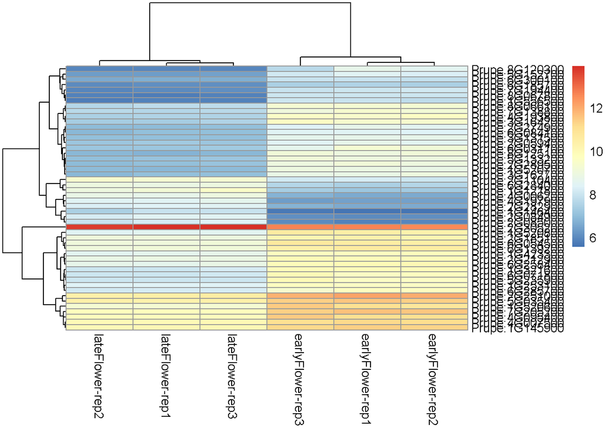

```r
## select count data only for the top 50 significant genes
rl.heatmap <- assay(rl.myDESeqData[rownames(myRes.sig[order(myRes.sig$padj), ])[1:50], ])

library(pheatmap)
pheatmap(rl.heatmap)
```

### Heatmap of the sample-to-sample distances

The distance between samples can be calculated using the `dist()` function of the transpose of the transformed count matrix. The heatmap shows the similarities between samples.

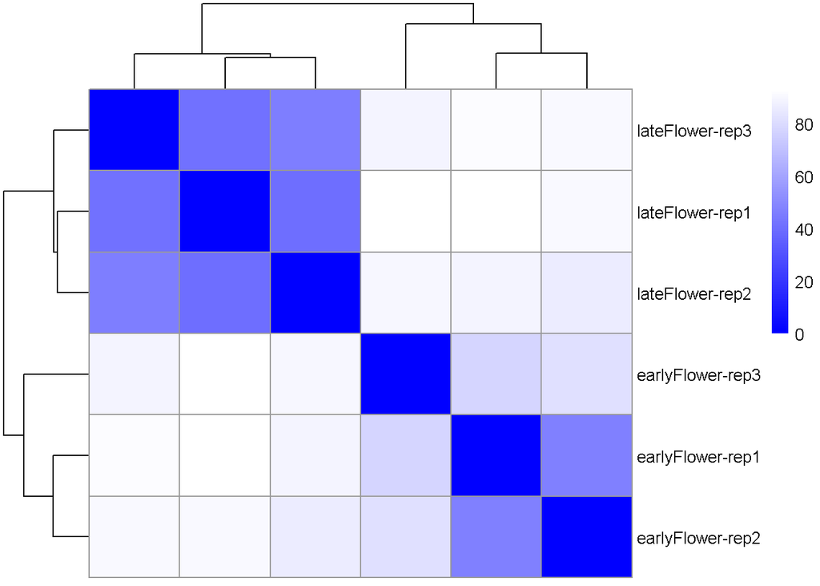

```r
sampleDists <- dist(t(assay(rl.myDESeqData)))
sampleDistMatrix <- as.matrix(sampleDists)
colnames(sampleDistMatrix) <- NULL
my_palette <- colorRampPalette(c( "Blue", "white"))(n = 100)
pheatmap(sampleDistMatrix, col=my_palette)
```

### Principal Component Analysis (PCA) plot of samples

This is another option to see distance of samples.

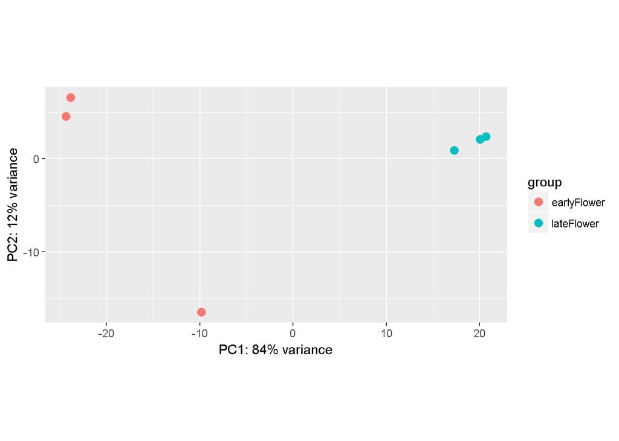

```r
plotPCA(rl.myDESeqData[rownames(myRes.sig), ], intgroup="pheno")
```

## Saving R workspace

After finishing, saving some results of the analysis into a file facilitates continuing with the analysis at another time point. Multiple R objects can be specified, separated by commas.

```r
save(myRes, file = "deseqRes.RData")
# load(file="deseqRes.RData")
```

## Preparing results for GO enrichment analysis

On the annotation file, there is a column with GO terms. GO enrichment can be done using the whole set of gene GO term annotations as reference to compare with the set of GO terms in our DEG. Next, we are going to process the GO terms contained in `anno` and `myRes.anno` in the format specified by the online tool [AgriGO](http://bioinfo.cau.edu.cn/agriGO/). * First column is an ID * Second column is a GO accession

On the annotation, there are genes with more than one GO accesion, separated by commas. We need to print one gene and one GO per line. * `strsplit` creates lists with the result of splitting a character string by the `split` character * `rep` is for replicate, print multiple copies of values in a vector + The vector to replicate contains the locus Names + The repeat times is given by counting the number of GO/locus after the split * `unlist` simplifies a list structure into a simple vector

```r
head(anno$GO)
```

```
## [1] "GO:0008536,GO:0006886"            "GO:0009733"
## [3] ""                                 "GO:0003824,GO:0006470,GO:0004722"
## [5] "GO:0005515"                       "GO:0046872"
```

```r
## print one gene and GO per line for the annotation file
s <- strsplit(anno$GO, split = ",")
anno.go <- data.frame(locus = rep(anno$locusName, sapply(s, length)), GO = unlist(s))
write.table(anno.go, file="go_ref_anno.txt", sep = " ", quote = F , row.names = F, col.names = F)

## check the column with locus names on myRes
head(myRes.anno, 2)
```

```
##        Row.names baseMean log2FoldChange     lfcSE      stat      pvalue
## 1 Prupe.1G000400 338.3011     -0.9944857 0.3399244 -2.925608 0.003437835
## 2 Prupe.1G000800 112.4128     -0.6136411 0.2259395 -2.715953 0.006608531
##         padj    pacId   transcriptName        peptideName    Pfam
## 1 0.02081537 32114906 Prupe.1G000400.1 Prupe.1G000400.1.p PF00481
## 2 0.03538100 32111851 Prupe.1G000800.1 Prupe.1G000800.1.p PF09229
##                     Panther     KOG  KEGG.ec     KO
## 1 PTHR13832,PTHR13832:SF329 KOG0698 3.1.3.16 K17506
## 2   PTHR13009,PTHR13009:SF5
##                                 GO Best.hit.arabi.name arabi.symbol
## 1 GO:0003824,GO:0006470,GO:0004722         AT4G28400.1
## 2            GO:0051087,GO:0001671         AT5G58110.1
##                           arabi.defline
## 1 Protein phosphatase 2C family protein
## 2   chaperone binding;ATPase activators
```

```r
## print one gene and GO each line for my results
s <- strsplit(myRes.anno$GO, split = ",")
myRes.go <- data.frame(locus = rep(myRes.anno$Row.names, sapply(s, length)), GO = unlist(s))
write.table(myRes.go, file="go_myRes.txt", sep = " ", quote = F, row.names = F, col.names = F)
```

With these two files, we are ready to move into [AgriGO](http://bioinfo.cau.edu.cn/agriGO/analysis.php). Select “Customized annotation” on both boxes and paste the content of `go_myRes.txt` on top and paste or load the reference annotation at the bottom. Finally, click submit and explore the results.